# Progetto Web and Social Mining

### Comparing distributions of lemmas Pre e Post Covid for Repubblica

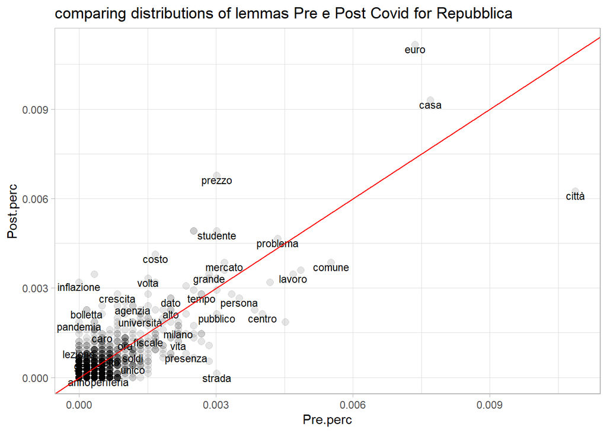

```r
tabL2prc <- tabL2ALL %>%
  mutate(Pre.perc=Pre_covid/sum(Pre_covid),
         Post.perc=Post_covid/sum(Post_covid),
         Tw.perc=Twitter/sum(Twitter),
        Red.perc=Reddit/sum(Reddit))

ggplot(tabL2prc, aes(Pre.perc,Post.perc)) +
  geom_point(alpha = 0.1, size = 2.5)+
  geom_text(aes(label = words),
            check_overlap = TRUE, vjust = 1,size=3)+
  geom_abline(color = "red")+
  theme_light()+
  ggtitle("comparing distributions of lemmas Pre e Post Covid for Repubblica")
```

### Zoom in order to better see the words

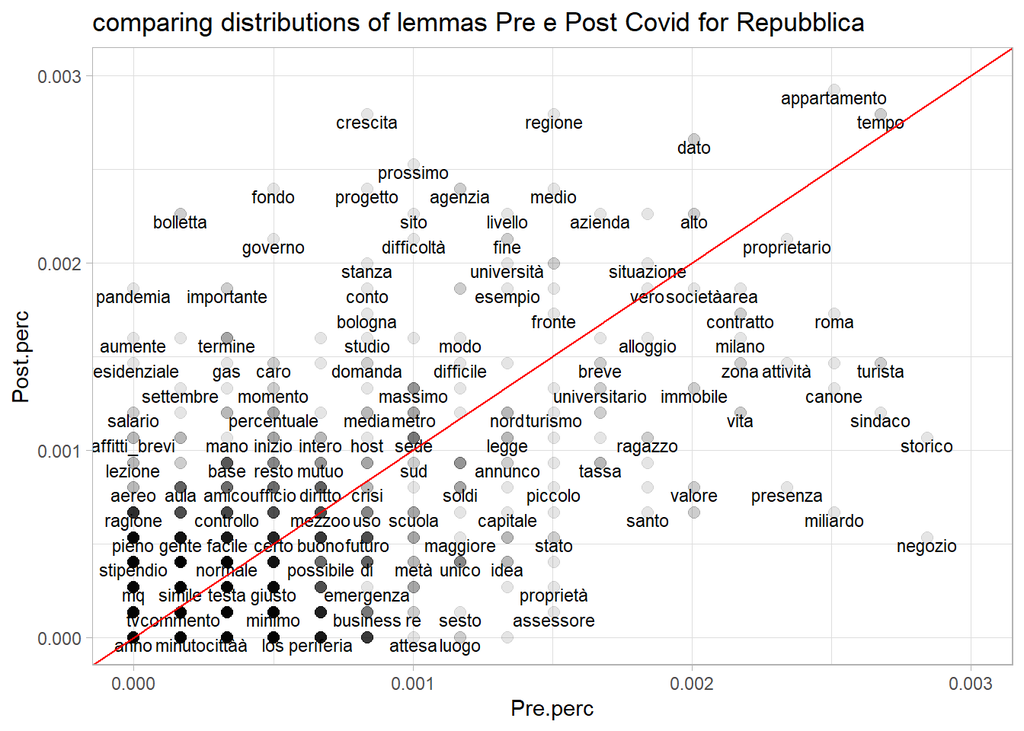

```r
ggplot(tabL2prc, aes(Pre.perc,Post.perc)) +
    geom_point(alpha = 0.1, size = 2.5)+
    geom_text(aes(label = words),
              check_overlap = TRUE, vjust = 1,size=3)+
    geom_abline(color = "red")+
    theme_light()+
    ylim(c(0,0.003))+
    xlim(c(0, 0.003))+
  ggtitle("comparing distributions of lemmas Pre e Post Covid for Repubblica")
```

## Comparing distributions of lemmas Twitter and Reddit

[figure not shown]

```r
ggplot(tabL2prc, aes(Tw.perc,Red.perc)) +
  geom_point(alpha = 0.1, size = 2.5)+
  geom_text(aes(label = words),
            check_overlap = TRUE, vjust = 1,size=3)+
  geom_abline(color = "red")+
  theme_light()+
  ggtitle("comparing distributions of lemmas Twitter and Reddit")
```

### which words are more or less likely to come from one of the two sources using the log odds ratio:

REPUBBLICA PRE E POST COVID

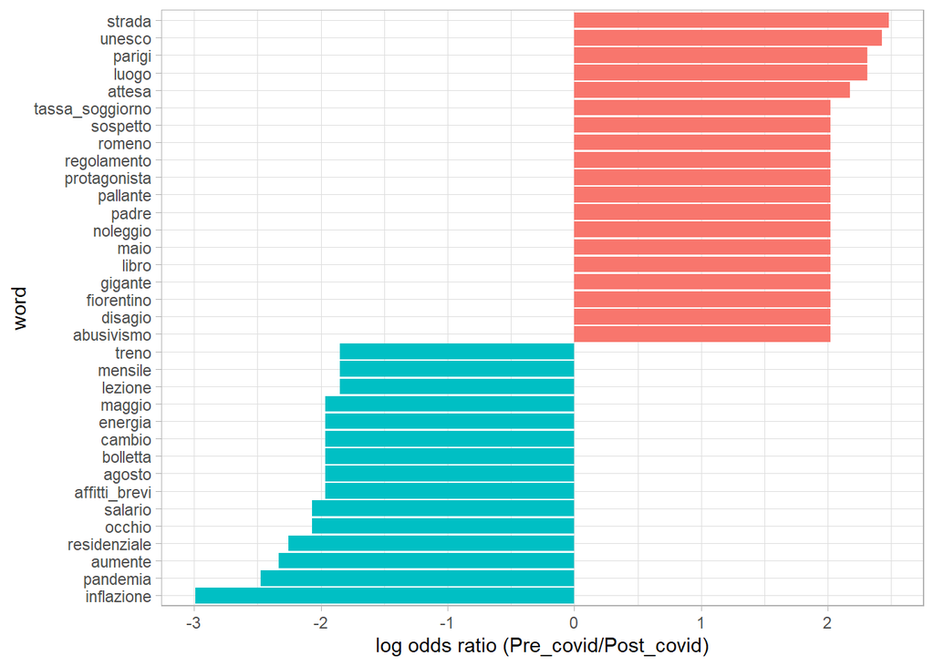

```r
tabL2prc %>%
  group_by(logratioPP < 0) %>%
  top_n(15, abs(logratioPP)) %>%
  ungroup() %>%
  mutate(word = reorder(words, logratioPP)) %>%
  ggplot(aes(word, logratioPP, fill = logratioPP < 0)) +
  geom_col(show.legend = FALSE) +
  coord_flip() +
  ylab("log odds ratio (Pre_covid/Post_covid)") +
  scale_fill_discrete(name = "",
                      labels=c("Pre_covid","Post_covid"))+
  theme_light()
```

### which words are more or less likely to come from one of the two sources using the log odds ratio: TW AND REDDIT

[figure not shown]

### Comparison cloud Pre-post Covid, Twitter and Reddit

[figure not shown]

### Commonality cloud Pre-post Covid, Twitter and Reddit

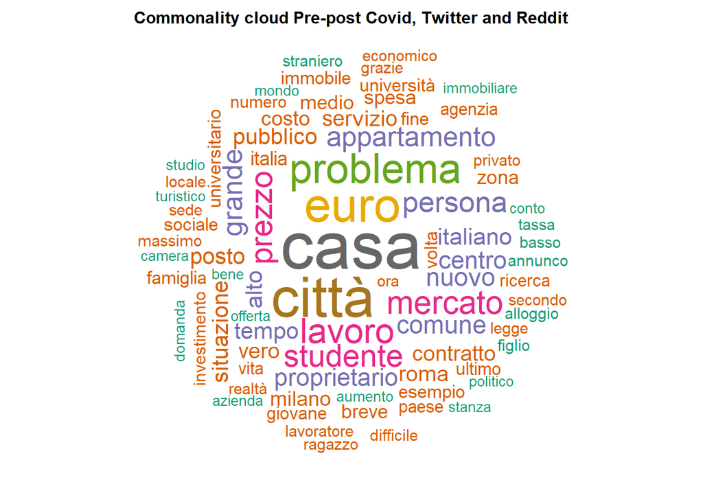

### With a comparison cloud it is possible to compare even more than two different contexts.

[figure not shown]

```r
comparison.cloud(mtdmL2ALL,max.words = 80, random.order=FALSE,
                 scale = c(3,0.4),
                 colors = cols25(n = 4),
                 title.size=2,match.colors = T)
text(0.5,0.99,"Comparison cloud
by class of number of lemmas",cex=1,font = 2)
```

### Comparison cloud with TF-IDF weighting

[figure not shown]

```r
pre<-dfCorpusALL%>%filter(source=="Pre")
corpus <- Corpus(VectorSource(pre$txtL))
tdm <- TermDocumentMatrix(corpus)
tdm
```

```
## <<TermDocumentMatrix (terms: 2584, documents: 135)>>
## Non-/sparse entries: 5123/343717
## Sparsity           : 99%
## Maximal term length: 26
## Weighting          : term frequency (tf)
```

# We take only observation of Repubblica (Pre covid), then we procede vectorizing the dataset

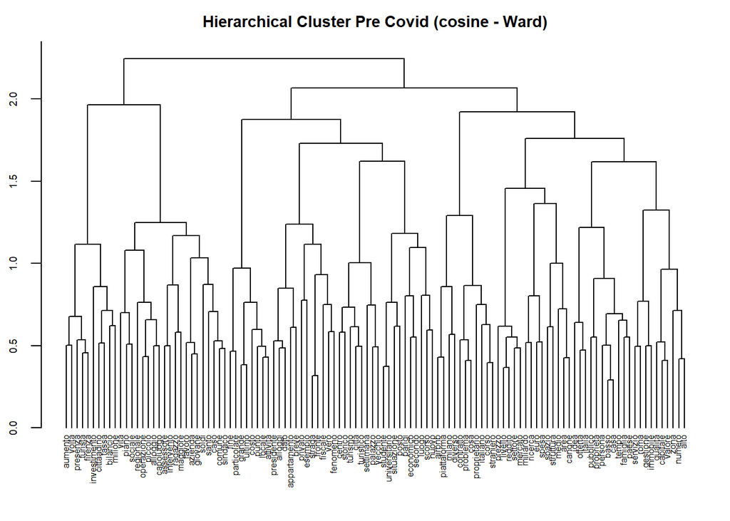

```r
# reduce matrix
tdm.r <- removeSparseTerms(tdm,sparse = 0.95)
# transform in a matrix object
mtdm.r <- as.matrix(tdm.r)
# compute distances
dst.tdm <- dist(mtdm.r,method = "cosine")
# Hierarchical Cluster
hhAc <- hclust(d = dst.tdm, method = "ward.D2")
# plot dendrogram
par(mar=c(1,2,2,1))
plot(hhAc, hang = -1,sub = "", cex=0.5,
     main="Hierarchical Cluster Pre Covid (cosine - Ward)",
     cex.main=0.9, xlab="", cex.axis=0.6, cex.lab=0.2)
```

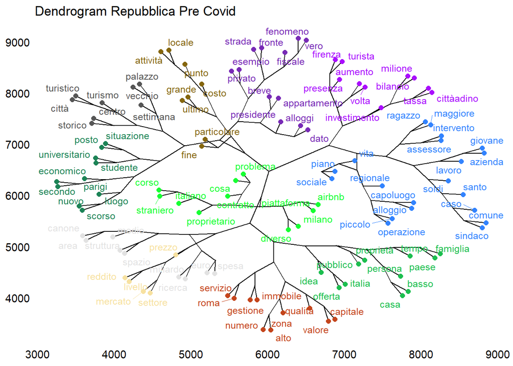

```r
fviz_dend(hhAc, k = 11,
          k_colors = alphabet2(n = 11),
          type = "phylogenic",
          repel = TRUE,
          phylo_layout = "layout.gem") +
  ggtitle("Dendrogram Repubblica Pre Covid")
```

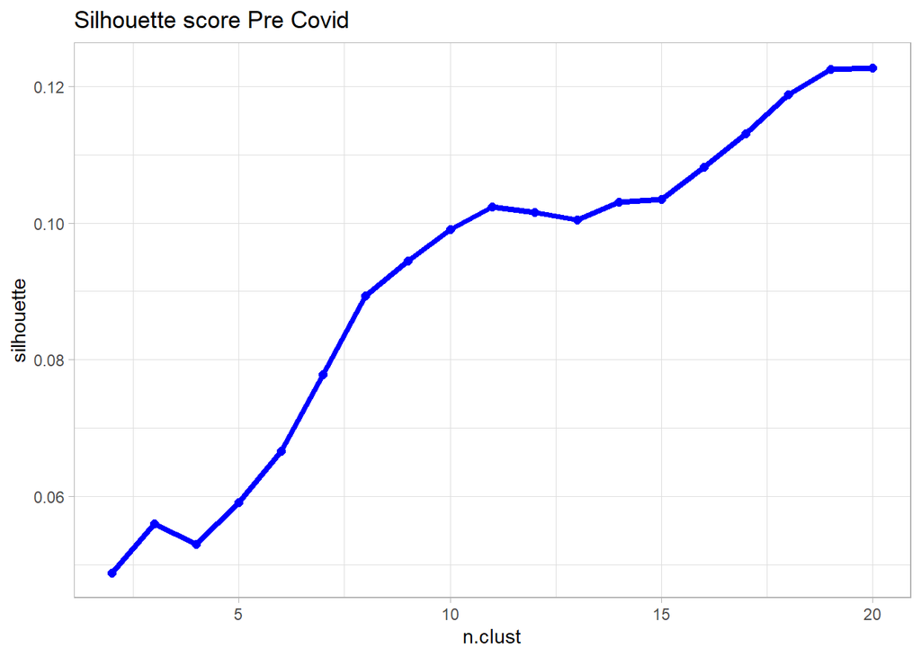

```r
# library with function silhouette
vSilIn <- c()
for(i in 2:20){
  vSilIn <- c(vSilIn,mean(silhouette(x = cutree(hhAc,k = i),dist = dst.tdm)[,3]))
}
data.frame(n.clust=2:20,silhouette=vSilIn) %>%
  ggplot(aes(x=n.clust,y=silhouette))+
  geom_line(color="blue",size=1.5)+geom_point(size=2,color="blue")+theme_light()+
  ggtitle("Silhouette score Pre Covid")
```

```r
nclu <- 9 # number of clusters
clust <- cutree(hhAc,k = nclu)
```

# clus pre covid rep

```r
cluPre$terms
```

```
## [1] "appartamento vero breve fenomeno fiscale privato strada alloggi presidente esempio dato fronte"
## [2] "basso casa offerta persona servizio capitale numero pubblico zona roma tempo proprietà gestione idea alto qualità famiglia italia valore immobile paese"
## [3] "euro prezzo medio spazio struttura spesa miliardo settore area canone livello mercato ricerca reddito"
## [4] "palazzo settimana città centro storico turistico vecchio turismo"
## [5] "turista aumento bilancio milione cittàadino investimento firenza presenza volta tassa"
## [6] "grande fine locale particolare costo ultimo punto attività"
## [7] "parigi scorso nuovo situazione luogo studente economico universitario posto secondo"
## [8] "caso lavoro piano sociale vita assessore intervento ragazzo alloggio operazione regionale capoluogo comune azienda giovane santo maggiore sindaco piccolo soldi"
## [9] "problema italiano corso milano straniero proprietario airbnb contratto cosa piattaforma diverso"
```

# clus post covid rep

```r
cluPost$terms
```

```
## [1] "casa impossibile occhio piattaforma turista appartamento totale richiesta bologna sito immobiliare agenzia mano studio airbnb stanza esempio affitti_brevo"
## [2] "problema persona azienda caso famiglia grazie momento milione regione contratto conto lavoro numero società alto comune firenza lavoratore metropolitano progetto pubblico possibilità tempo campo nuovo strumento governo centro fine misura ultimo canone camera sociale nazionale contributo"
## [3] "universitario università importante servizio termine fondo studente vero fronte alloggio posto ricerca risorsa tema cosa"
## [4] "città grande secondo dato italiano struttura attività inizio area pandemia settore spazio livello settimana spesa milano giovane crescita economico medio gruppo giugno roma"
## [5] "sindaco qualità storico turistico breve amministrazione modo legge"
## [6] "vita consumo energia euro internazionale italia locale scorso settembre reddito aumento bolletta presidente volta costo caro prossimo impresa situazione prezzo difficile ora politico"
## [7] "inflazione lungo mercato tasso agosto rincaro residenziale domanda offerta locazione"
## [8] "punto paese proprietario difficoltà"
```

# clus twi

```r
cluTwitter$terms
```

```
## [1] "anno appartamento casa prezzo affitti_brevo centro parte proprietario cazzo persona altro legge mercato italia problema alto primo paese zona"
## [2] "stanza studente università città bologna stella caro emergenza universitario situazione"
## [3] "tassa cosa gente famiglia lavoro spesa bolletta soldo"
## [4] "bonus comune contributo nero nuovo canone diritto domanda milione"
## [5] "milano mese euro monolocale"
## [6] "vita costo stipendio"
```

# clus reddit

```r
cluReddit$terms
```

```
##  [1] "bologna università città milano milare grande bello italia posto"
##  [2] "euro mese anno parte lavoro appartamento maggiore cazzo primo conto vita costo paese italiano piccolo"
##  [3] "studente lavoratore possibile problema universitario roma simile"
##  [4] "mutuo economico questione sede lezione momento sistema"
##  [5] "stato senso mercato privato pubblico tassa"
##  [6] "airbnb breve casa proprietario contratto esperienza facile turista fine accordo comune periodo nuovo semplice"
##  [7] "prezzo domanda zona medio alto stipendio mezzo centro basso legge"
##  [8] "situazione stanza giorno buono grazie ragazzo giusto vero ora"
##  [9] "tempo gente unico realtà corso mondo esempio servizio migliore motivo soluzione possibilità punto"
## [10] "minuto resto metro volta commento termine"
## [11] "agenzia via persona soldo immobile post"
## [12] "diritto studio"
```